UFSM: 2018/1; Notas de aula: Mecânica Quântica; Autor: Jonas Maziero

```python
import numpy as np
from matplotlib import pyplot as plt
from sympy import *
init_printing(use_unicode=True)
```

# Operador densidade e entropia

## O operador densidade

Vimos que o significado de dizermos que um sistema quântico foi preparado em um determinado estado $|\psi\rangle$ é que sabemos que um observável foi medido e que se selecionou o autovalor correspondente a este autovetor. Vamos supor que temos somente informação parcial sobre a preparação do sistema. Ou seja, considere que sabemos que o sistema foi preparado no estado $|\psi_{j}\rangle$ com probabilidade $p_{j}$, mas para cada "partícula" que nos é apresentada não sabemos qual é o valor de $j$ (i.e., o índice $J$ é uma variável aleatória). Como podemos calcular probabilidades de medidas futuras de um observável $O$? Bom, para cada medida que faremos de $O$, o sistema estará em um dos estados $\{|\psi_{j}\rangle\}$. Então, para o conjunto de partículas no estado $|\psi_{j}\rangle$, segue valendo a regra de Born: \begin{equation} Pr(o|\psi_{j}) = |\langle\psi_{j}|o\rangle|^{2}. \end{equation} Para obter a probabilidade para todo o ensemble $\{p_{j},|\psi_{j}\rangle\}$ consideramos a média: \begin{align} Pr(o|\{p_{j},|\psi_{j}\rangle\}) & = \sum_{j} Pr(o|\psi_{j})p_{j} \\ & = \sum_{j} \langle o|\psi_{j}\rangle\langle\psi_{j}|o\rangle p_{j} \\ & = \langle o|\sum_{j} p_{j}|\psi_{j}\rangle\langle\psi_{j}|o\rangle \\ & =: \langle o|\rho|o\rangle, \end{align} onde definimos o chamado *operador densidade* como \begin{equation} \rho := \sum_{j} p_{j}|\psi_{j}\rangle\langle\psi_{j}|. \end{equation} *OBS:* Os estados $\{|\psi_{j}\rangle\}$ não precisam ser mutuamente ortogonais. Ademais, o índice $j=1,\cdots,N$ e $N$ pode ser menor, igual ou maior que a dimensão do espaço de estados do sistema $d=\dim\mathcal{H}$.  
**Exercício:** Forneça um exemplo de cada caso.

*OBS:* Podem existir vários ensembles $\{p_{j},|\psi_{j}\rangle\}$ diferentes que nos levam ao mesmo operador densidade. Ou seja, há arbitrariedade quando fazemos o caminho $\rho\rightarrow\{p_{j},|\psi_{j}\rangle\}$.  
**Exercício:** Para sistemas de dois níveis, forneça dois ensembles "diferentes" que levam ao mesmo estado $\rho=\sigma_{0}/2$.

*OBS:* No contexto do operador densidade, temos dois tipos de incerteza, a clássica, codificada nas probabilidades dos diferentes estados do ensemble, e a quântica, devida ao fato de que estes estados, individualmente, podem ser superposições dos autovetores do observável a ser medido.

*OBS:* Repetibilidade continua valendo para identificar estados preparados.

**Exercício:** Verifque que \begin{equation} Pr(o|\rho) = \mathrm{Tr}(\rho|o\rangle\langle o|) =: \mathrm{Tr}(\rho\Pi_{o}), \end{equation} com a função traço definida como $\mathrm{Tr}(X)=\sum_{j}\langle b_{j}|X|b_{j}\rangle$ para $\{|b_{j}\rangle\}$ qualquer base ortonormal do espaço de Hilbert sendo considerado.

**Exercício:** Verifique que o valor médio de um observável $O$ (com espectro contínuo ou discreto) para um sistema preparado no estado $\rho$ pode ser escrito como: \begin{equation} \langle O\rangle_{\rho} = \mathrm{Tr}(\rho O). \end{equation}

### Propriedades de $\rho$

Então, podemos diagonalizar $\rho = \sum_{j}r_{j}|r_{j}\rangle\langle r_{j}|$. Claro, podemos interpretar esse $\rho$ como representando o ensemble $\{r_{j},|r_{j}\rangle\}$. Por isso os autovalores $r_{j}$ devem ser positivos (além de $\sum_{j}r_{j}=1$). Garantimos positividade dos autovalores exigindo de forma geral que \begin{equation} \rho\ge \mathbb{0}. \end{equation}

### Exemplo

Para partículas de spin 1/2, consideremos que alguém prepara $|z_{+}\rangle$ com probabilodade $p$ ou $|x_{+}\rangle$ com probabilodade $1-p$. O operador densidade associado a esse ensemble $\{(p,|z_{+}\rangle),(1-p,|z_{-}\rangle)\}$ será: \begin{align} \rho & = p|z_{+}\rangle\langle z_{+}| + (1-p)|x_{+}\rangle\langle x_{+}| \\ & = p|z_{+}\rangle\langle z_{+}| + 2^{-1}(1-p)(|z_{+}\rangle+|z_{-}\rangle)(\langle z_{+}|+\langle z_{-}|) \\ & = p|z_{+}\rangle\langle z_{+}| + 2^{-1}(1-p)(|z_{+}\rangle\langle z_{+}|+|z_{-}\rangle\langle z_{+}| + |z_{+}\rangle\langle z_{-}|+|z_{-}\rangle\langle z_{-}|) \\ & = 2^{-1}(1+p)|z_{+}\rangle\langle z_{+}| + 2^{-1}(1-p)|z_{-}\rangle\langle z_{-}| + 2^{-1}(1-p)(|z_{-}\rangle\langle z_{+}| + |z_{+}\rangle\langle z_{-}|) \\ & = \frac{1}{2}\begin{bmatrix} 1+p & 1-p \\ 1-p & 1-p \end{bmatrix}. \end{align} Acima usamos $|x_{\pm}\rangle = (|z_{+}\rangle \pm |z_{-}\rangle)/\sqrt{2}$.

Probabilidades para medidas de $\sigma_{y}$: \begin{align} Pr(y_{+}|\rho) & = \langle y_{+}|\rho| y_{+}\rangle \\ & = p\langle y_{+}|z_{+}\rangle\langle z_{+}|y_{+}\rangle + (1-p)\langle y_{+}|x_{+}\rangle\langle x_{+}|y_{+}\rangle \\ & = p|\langle z_{+}|y_{+}\rangle|^{2} + (1-p)|\langle x_{+}|y_{+}\rangle|^{2} \\ & = p|1/\sqrt{2}|^{2} + (1-p)|(1+i)/2|^{2} \\ & = p/2 + (1-p)/2 \\ & = 1/2 \\ Pr(y_{-}|\rho) & = 1/2. \end{align} Acima usamos $|y_{+}\rangle = (|z_{+}\rangle + i|z_{-}\rangle)/\sqrt{2}$.

**Exercício:** Considere que $|z_{+}\rangle$ é preparado com probabilidade $3/4$ e que $|y_{+}\rangle$ é preparado como probabilidade $1/4$. Obtenha a matriz densidade, na base padrão, para o operador densidade que representa esse ensemble. Usse esse operador para calcular as probabilidades para a componente de spin na direção $\hat{n} = (1/\sqrt{2},0,1/\sqrt{2})$.

## Equação de von Neumann (EN)

Considere um sistema preparado no estado $\rho = \sum_{j} p_{j}|\psi_{j}\rangle\langle\psi_{j}| \equiv \{p_{j},|\psi_{j}\rangle\}$. Digamos que este sistema evolui por um tempo $t$ segundo o Hamiltoniano $H_{t}$. Qual será o operador densidade evoluído desse sistema? Da ideia de ensemble sabemos que é cada um dos estados $|\psi_{j}\rangle$ que evoluirá no tempo. Ou seja, no tempo $t$ teremos o novo ensemble $\{p_{j},|\psi_{j}(t)\rangle\}$ com \begin{equation} |\psi_{j}(t)\rangle = U_{t}|\psi_{j}\rangle. \end{equation} Então \begin{align} \rho_{t} & = \sum_{j} p_{j}|\psi_{j}(t)\rangle\langle\psi_{j}(t)| \\ & = \sum_{j} p_{j}U_{t}|\psi_{j}\rangle\langle\psi_{j}|U_{t}^{\dagger} \\ & = U_{t}\sum_{j} p_{j}|\psi_{j}\rangle\langle\psi_{j}|U_{t}^{\dagger} \\ & = U_{t}\rho U_{t}^{\dagger}. \end{align}

Derivando essa equação em relação ao tempo e usando a eq. de Schrödinger, \begin{equation} i\hbar\partial_{t}U_{t} = H_{t}U_{t}, \end{equation} obteremos a EN: \begin{align} i\hbar\partial_{t}\rho_{t} & = i\hbar\partial_{t}(U_{t})\rho U_{t}^{\dagger} + 0 + U_{t}\rho i\hbar\partial_{t}(U_{t}^{\dagger}) \\ & = H_{t}U_{t}\rho U_{t}^{\dagger} - U_{t}\rho U_{t}^{\dagger}H_{t} \\ & = H_{t}\rho_{t} - \rho_{t}H_{t} \\ & = [H_{t},\rho_{t}]. \end{align}

### Exemplo

As matrizes $\{\sigma_{j}/\sqrt{2}\}_{j=0}^{3}$ formam uma base ortonormal para $\mathbb{C}^{2x2}$, sob o produto interno de Hilbert-Schmidt $\langle A|B\rangle = \mathrm{Tr}(A^{\dagger}B)$. Por conseguinte, qualquer operador densidade pode ser escrito como \begin{align} \rho & = \sum_{j=0}^{3} \mathrm{Tr}\left(\rho\frac{\sigma_{j}}{\sqrt{2}}\right)\frac{\sigma_{j}}{\sqrt{2}} \\ & = \frac{1}{2}\sum_{j=0}^{3}\langle\sigma_{j}\rangle_{\rho}\sigma_{j} \\ & =: \frac{1}{2}\left(\sigma_{0} + \sum_{j=1}^{3}r_{j}\sigma_{j}\right) \\ & = \frac{1}{2}\begin{bmatrix} 1+r_{3} & r_{1}-i r_{2} \\ r_{1}-i r_{2} & 1-r_{3} \end{bmatrix}, \end{align} em que usamos $\langle\sigma_{0}\rangle_{\rho}=1$.  
**Exercício:** Verifique que os autovalores de $\rho$ são $(1\pm r)/2$, com $r = \sqrt{\sum_{j=1}^{3}r_{j}^{2}}$.  
*OBS:* Pela positividade do operador densidade estados físicos estão dentro de uma bola de raio 1 em $\mathbb{R}^{3}$ centrada em (0,0,0). As componentes do ponto de $\mathbb{R}^{3}$ que representa $\rho$ são $(r_{1},r_{2},r_{3})$, que é chamado de *vetor de Bloch*.

Consideremos um spin 1/2 em um estado qualquer $\rho_{t}=\frac{1}{2}\left(\sigma_{0} + \sum_{j=1}^{3}r_{j}(t)\sigma_{j}\right)$ e evoluindo sob o Hamiltoniano $H=-2^{-1}\hbar\omega\sigma_{3}$. Teremos assim que \begin{align} i\hbar\partial_{t}\rho_{t} & = [H_{t},\rho_{t}] \\ i\hbar\partial_{t}\frac{1}{2}\begin{bmatrix} 1+r_{3}(t) & r_{1}(t)-i r_{2}(t) \\ r_{1}(t)-i r_{2}(t) & 1-r_{3}(t) \end{bmatrix} & = [-2^{-1}\hbar\omega\sigma_{3},2^{-1}(\sigma_{0}+r_{1}(t)\sigma_{1}+r_{2}(t)\sigma_{2}+r_{3}(t)\sigma_{3})] \\ \frac{i\hbar}{2}\begin{bmatrix} 0+\partial_{t}r_{3}(t) & \partial_{t}r_{1}(t)-i \partial_{t}r_{2}(t) \\ \partial_{t}r_{1}(t)-i \partial_{t}r_{2}(t) & 0-\partial_{t}r_{3}(t) \end{bmatrix} & = -\frac{\hbar\omega}{4}[\sigma_{3},\sigma_{0}+r_{1}(t)\sigma_{1}+r_{2}(t)\sigma_{2}+r_{3}(t)\sigma_{3}] \\ & = -\frac{\hbar\omega}{4}\left(\mathbb{0} + r_{1}(t)2i\epsilon_{312}\sigma_{2}+ r_{2}(t)2i\epsilon_{321}\sigma_{1}+\mathbb{0}\right) \\ & = -\frac{i\hbar\omega}{2}\left(r_{1}(t)\sigma_{2} - r_{2}(t)\sigma_{1}\right) \\ & = \frac{i\hbar\omega}{2}\begin{bmatrix} 0 & r_{2}(t)+ir_{1}(t) \\ r_{2}(t)-ir_{1}(t) & 0 \end{bmatrix} \\ \end{align} Primeiro observe que $\partial_{t}r_{3}(t) = 0 \Rightarrow r_{3}(t)=r_{3}$. Resta-nos resolver o seguinte sistema de eqs. diferenciais lineares de primeira ordem acopladas: \begin{align} \begin{cases} \partial_{t}r_{1}(t) = \omega r_{2}(t), \\ \partial_{t}r_{2}(t) = -\omega r_{1}(t). \end{cases} \end{align} Do qual obtemos o sistema de eqs. diferenciais lineares de segunda ordem desacopladas: \begin{align} \begin{cases} \partial_{tt}r_{1}(t) = \omega \partial_{t}r_{2}(t) = -\omega^{2}r_{1}(t), \\ \partial_{tt}r_{2}(t) = -\omega \partial_{t}r_{1}(t) = -\omega^{2}r_{2}(t), \end{cases} \end{align} cuja solução pode ser escrita como: \begin{align} \begin{cases} r_{1}(t) = r_{1}\cos\omega t + r_{2}\sin\omega t, \\ r_{2}(t) = -r_{1}\sin\omega t + r_{2}\cos\omega t,\\ r_{3}(t)=r_{3}. \end{cases} \end{align} Matriz densidade evoluída: \begin{align} \rho_{t} & = \begin{bmatrix} 1+r_{3}(t) & r_{1}(t)-ir_{2}(t) \\ r_{1}(t)+ir_{2}(t) & 1+r_{3}(t) \end{bmatrix} \\ & = \vdots \\ & = \begin{bmatrix} 1+r_{3} & (r_{1}-ir_{2})e^{i\omega t} \\ (r_{1}+ir_{2})e^{-i\omega t} & 1+r_{3} \end{bmatrix}. \end{align}

**Exercício:** Considere o mesmo sistema do último exemplo, mas obtenha o estado evoluído usando $\rho_{t}=U_{t}\rho U_{t}^{\dagger}$ com $U_{t}=e^{-iHt/\hbar}$.

## Entropia

Existe uma diferença fundamental entre a incerteza clássica associada ao operador densidade e a incerteza quântica associada com superposição. Esses dois tipos de incerteza podem coexistir. A seguir definiremos funções que podem ser utilizadas para quantificar essas incertezas distintivamente.

### Entropia linear (EL)

A *pureza* de um operador densidade é definida com \begin{equation} P(\rho) = \mathrm{Tr}(\rho^{2}). \end{equation} A EL é definida como: \begin{equation} S_{L}(\rho) = 1-P(\rho). \end{equation} **Exercício:** Verifique as igualdades em: $S_{L}(\mathbb{I}/d) = (d-1)/d \ge S_{L}(\rho) \ge 0 = S_{L}(|\psi\rangle)$.

### Entropia de von Neumann (EN)

\begin{equation} S_{vN}(\rho) = -\mathrm{Tr}(\rho\log_{2}\rho) = H(\{r_{j}\}), \end{equation} onde $H(\{r_{j}\})=-\sum_{j}r_{j}\log_{2}r_{j}$ é a *entropia de Shannon* e $r_{j}$ são os autovalores de $\rho$.  
*OBS:* Usamos $\log_{2}$ para medir entropia em bits.  
*OBS:* Em termodinâmica usa-se $\ln=\log_{e}$ no lugar de $\log_{2}$ e a expressão da entropia é multiplicada por $k_{B}$, a constante de Boltzmann.  
*OBS:* Ao calcular $S_{vN}$ usamos $\lim_{x\rightarrow 0} x\log x = 0$ para fazer $0\log 0 = 0$.  
**Exercício:** Verifique as igualdades em: $S_{vN}(\mathbb{I}/d) = \log_{2}d \ge S_{vN}(\rho) \ge 0 = S_{vN}(|\psi\rangle)$.

### Entropia de Wigner-Yanase (EWY)

Enquanto as EL e EN quantificam incerteza clássica, a EWY quantifica incerteza quântica em relação a um observável $O$ para um sistema no estado $\rho$: \begin{align} S_{wy}(O|\rho) & = -\frac{1}{2}\mathrm{Tr}\left([\sqrt{\rho},O]^{2}\right) \\ & = -\frac{1}{2}\mathrm{Tr}\left((\sqrt{\rho}O-O\sqrt{\rho})^{2}\right) \\ & = -\frac{1}{2}\mathrm{Tr}\left( (\sqrt{\rho}O-O\sqrt{\rho})(\sqrt{\rho}O-O\sqrt{\rho}) \right) \\ & = -\frac{1}{2}\mathrm{Tr}\left( \sqrt{\rho}O\sqrt{\rho}O -O\sqrt{\rho}\sqrt{\rho}O - \sqrt{\rho}OO\sqrt{\rho} +O\sqrt{\rho}O\sqrt{\rho} \right) \\ & = -\frac{1}{2}\left( \mathrm{Tr}(\sqrt{\rho}O\sqrt{\rho}O) - \mathrm{Tr}(O\rho O) - \mathrm{Tr}(\sqrt{\rho}O^{2}\sqrt{\rho}) + \mathrm{Tr}(O\sqrt{\rho}O\sqrt{\rho}) \right) \\ & = \mathrm{Tr}(\rho O^{2}) - \mathrm{Tr}(\sqrt{\rho}O\sqrt{\rho}O) \\ & = \langle O^{2}\rangle_{\rho} - \mathrm{Tr}\left((O\sqrt{\rho})^{2}\right). \end{align} *OBS:* Note que se $\rho$ e $O$ comutam, a EWY é nula, mesmo que nossa incerteza clássica sobre o estado do sistema seja positiva.  
**Exercício:** Verifique que para estados puros $S_{wy}(O|\rho)=\mathrm{Var}(O)_{\psi}$.

#### Exemplo

*OBS:* O comprimento do vetor de Bloch não muda por transformações unitárias.  
Para verificar essa informação, considera $\rho'=U\rho U^{\dagger}$. Para sistemas de 2 níveis \begin{align} P(\rho) & = \mathrm{Tr} \frac{1}{2}\left(\sigma_{0} + \sum_{j=1}^{3}r_{j}\sigma_{j}\right)\frac{1}{2}\left(\sigma_{0} + \sum_{k=1}^{3}r_{k}\sigma_{k}\right) \\ & = \frac{1}{4}\mathrm{Tr}\left(\sigma_{0} + 2\sum_{j=1}^{3}r_{j}\sigma_{j} + \sum_{j,k=1}^{3}r_{j}r_{k}\sigma_{j}\sigma_{k} \right) \\ & = \frac{1}{4}\left(2 + 0 + \sum_{j,k=1}^{3}r_{j}r_{k}\mathrm{Tr}(\sigma_{j}\sigma_{k}) \right) \\ & = \frac{1}{4}\left(2 + \sum_{j,k=1}^{3}r_{j}r_{k}2\delta_{jk} \right) \\ & = \frac{1}{2}\left(1 + r^{2} \right). \end{align} Pela invariância da função traço sob transformações unitárias (mudança de base), \begin{align} P(\rho') & = \frac{1}{2}\left(1 + r'^{2} \right) \\ & = \mathrm{Tr}(U\rho U^{\dagger}U\rho U^{\dagger}) \\ & = \mathrm{Tr}(U\rho\rho U^{\dagger}) \\ & = \mathrm{Tr}(\rho^{2}). \end{align} Portanto $r'=r$. Ou seja, tranformações unitárias somente giram o vetor de Bloch em $\mathbb{R}^{3}$.

Vamos calcular aquelas três entropias para o estado geral de um sistema de 2 níveis mostrado acima. Da expressão para a pureza vem que \begin{equation} S_{L}(\rho) = \frac{1-r^{2}}{2}. \end{equation} Já, dos autovalores de $\rho$, a EN fica \begin{align} S_{vN}(\rho) & = -\frac{1+r}{2}\log_{2}\frac{1+r}{2} - \frac{1-r}{2}\log_{2}\frac{1-r}{2} \\ & = \vdots \\ & = 1 - 2^{-1}[(1+r)\log_{2}(1+r) + (1-r)\log_{2}(1-r)]. \end{align}

Para obter $S_{wy}$ consideraremos como observável $\sigma_{z}$. Nesse caso, como $\sigma_{z}^{2}=\sigma_{0}$, fazendo $\rho=r_{+}|r_{+}\rangle\langle r_{+}|+r_{-}|r_{-}\rangle\langle r_{-}|$ com $r_{\pm}=(1\pm r)/2$ e $|r_{+}\rangle = \cos(\theta/2)|z_{+}\rangle + e^{i\phi}\sin(\theta/2)|z_{-}\rangle$ e $|r_{-}\rangle = \sin(\theta/2)|z_{+}\rangle - e^{i\phi}\cos(\theta/2)|z_{-}\rangle$. Assim, usando $\sigma_{z}|r_{+}\rangle = \cos(\theta/2)|z_{+}\rangle - e^{i\phi}\sin(\theta/2)|z_{-}\rangle$, $\sigma_{z}|r_{-}\rangle=\sin(\theta/2)|z_{+}\rangle + e^{i\phi}\cos(\theta/2)|z_{-}\rangle$ e $\mathrm{Tr}(A|\psi\rangle\langle\psi|)=\langle\psi|A|\psi\rangle$ obteremos \begin{align} S_{wy}(\sigma_{z}|\rho) & = \mathrm{Tr}(\rho) - \mathrm{Tr}\left((\sigma_{z}\sqrt{\rho})^{2}\right) \\ & = 1 - \mathrm{Tr}\left((\sigma_{z}(\sqrt{r_{+}}|r_{+}\rangle\langle r_{+}|+\sqrt{r_{-}}|r_{-}\rangle\langle r_{-}|))^{2}\right) \\ & = 1 - \mathrm{Tr}(\sqrt{r_{+}}\sigma_{z}|r_{+}\rangle\langle r_{+}| + \sqrt{r_{-}}\sigma_{z}|r_{-}\rangle\langle r_{-}|)^{2} \\ & = 1 - \mathrm{Tr}\left(r_{+}\sigma_{z}|r_{+}\rangle\langle r_{+}|\sigma_{z}|r_{+}\rangle\langle r_{+}| + \sqrt{r_{+}r_{-}}\sigma_{z}|r_{+}\rangle\langle r_{+}|\sigma_{z}|r_{-}\rangle\langle r_{-}| + \sqrt{r_{+}r_{-}}\sigma_{z}|r_{-}\rangle\langle r_{-}|\sigma_{z}|r_{+}\rangle\langle r_{+}| + r_{-}\sigma_{z}|r_{-}\rangle\langle r_{-}|\sigma_{z}|r_{-}\rangle\langle r_{-}| \right) \\ & = 1 - r_{+}\langle r_{+}|\sigma_{z}|r_{+}\rangle^{2} - 2\sqrt{r_{+}r_{-}}|\langle r_{-}|\sigma_{z}|r_{+}\rangle|^{2} - r_{-}\langle r_{-}|\sigma_{z}|r_{-}\rangle^{2} \\ & = 1 - r_{+}(\cos^{2}(\theta/2)-\sin^{2}(\theta/2))^{2} - 2\sqrt{r_{+}r_{-}}|2\sin(\theta/2)\cos(\theta/2)|^{2} - r_{-}(\sin^{2}(\theta/2)-\cos^{2}(\theta/2))^{2} \\ & = 1 - 2^{-1}(1+r)\cos^{2}\theta - \sqrt{1-r^{2}}\sin^{2}\theta - 2^{-1}(1-r)\cos^{2}\theta \\ & = 1 - \cos^{2}\theta - \sqrt{1-r^{2}}\sin^{2}\theta \\ & = (1-\sqrt{1-r^{2}})\sin^{2}\theta. \end{align}

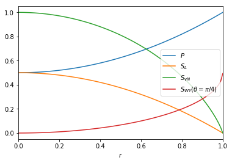

```python
N, r, dr, th = symbols('N r dr theta')
N = 100
dr = (1.01-0)/N
rv = np.zeros(N)
P = np.zeros(N)
Sl = np.zeros(N)
Sn = np.zeros(N)
Swy = np.zeros(N)
th = np.pi/4
r = -dr
for j in range(0,N):
    r += dr
    rv[j] = r
    P[j] = (1+r**2)/2
    Sl[j] = 1-P[j]
    Sn[j] = 1-(1/2)*((1+r)*log(1+r,2) + (1-r)*log(1-r,2))
    Swy[j] = (1-sqrt(1-r**2))*(sin(th))**2
plt.xlabel(r'$r$')
plt.plot(rv, P, label=r'$P$')
plt.plot(rv, Sl, label=r'$S_{L}$')
plt.plot(rv, Sn, label=r'$S_{vN}$')
plt.plot(rv, Swy, label=r'$S_{WY}(\theta=\pi/4)$')
axes = plt.gca()
axes.set_xlim([0,1])
#axes.set_ylim([,])
plt.legend()
plt.show()
```

## Estado térmico de Gibbs

Emaranhamento do sistema com seu ambiente, que possui temperatura $T$ e é "muito grande", fará com que o estado de equilíbrio do primeiro tenha a seguinte forma [arXiv:quant-ph/0511225]: \begin{equation} \rho_{th} = \frac{e^{-\beta H}}{Z} = \sum_{j} \frac{e^{-\beta E_{j}}}{Z}|E_{j}\rangle\langle E_{j}| = \sum_{j} Pr(E_{j})|E_{j}\rangle\langle E_{j}|, \end{equation} em que $\beta = 1/k_{B}T$, $H=\sum_{j}E_{j}|E_{j}\rangle\langle E_{j}|$ é o Hamiltoniano do sistema e a normalização (para que $\mathrm{Tr}(\rho_{th})=1$) é a função de partição: \begin{equation} Z = \mathrm{Tr}\left(e^{-\beta H}\right) = \sum_{j}e^{-\beta E_{j}}. \end{equation}

Nesse caso, \begin{align} S_{th}(\rho_{th}) & = k_{B}\ln 2 S_{vN}(\rho_{th}) \\ & = - k_{B}\mathrm{Tr}(\rho_{th}\ln\rho_{th}) = H\left(\left\{\frac{e^{-\beta E_{j}}}{Z}\right\}\right) \\ & = - k_{B}\sum_{j}\frac{e^{-\beta E_{j}}}{Z}\ln\frac{e^{-\beta E_{j}}}{Z} \\ & = - k_{B}\sum_{j}\frac{e^{-\beta E_{j}}}{Z}(\ln e^{-\beta E_{j}} - \ln Z) \\ & = - k_{B}\left(-\beta\sum_{j}\frac{e^{-\beta E_{j}}}{Z} E_{j}-\ln Z\sum_{j}\frac{e^{-\beta E_{j}}}{Z}\right) \\ & = k_{B}\frac{1}{k_{B}T} \langle H\rangle + k_{B}\ln Z \\ \end{align} ou \begin{equation} -k_{B}T\ln Z =: F = \langle H\rangle - TS_{th}. \end{equation}

### Exemplo

Considere um spin 1/2 com Hamiltoniano $H=-(\hbar\omega/2)\sigma_{z} = E_{+}|z_{+}\rangle\langle z_{+}|+E_{-}|z_{-}\rangle\langle z_{-}|$. Primeiro calculamos a função de partição \begin{align} Z & = \mathrm{Tr}(e^{-\beta H}) = \sum_{j}e^{-\beta E_{j}} \\ & = e^{-\beta E_{+}} + e^{-\beta E_{-}} \\ & = e^{-\beta (-\hbar\omega/2)} + e^{-\beta(\hbar\omega/2)} \\ & = 2\cosh\frac{\beta\hbar\omega}{2}. \end{align} Energia média \begin{align} \langle H\rangle & = E_{+}Pr(E_{+}) + E_{-}Pr(E_{-}) \\ & = \frac{-\hbar\omega}{2}\frac{e^{\beta\hbar\omega/2}}{Z} + \frac{\hbar\omega}{2}\frac{e^{-\beta\hbar\omega/2}}{Z} \\ & = \vdots \\ & = -\frac{\hbar\omega}{2}\tanh\frac{\beta\hbar\omega}{2}. \end{align} Entropia \begin{align} \frac{S_{th}}{k_{B}} & = \frac{\langle H\rangle}{T} + k_{B}\ln Z \\ & = \frac{-\frac{\hbar\omega}{2}\tanh\frac{\beta\hbar\omega}{2}}{k_{B}T} + \ln\left(2\cosh\frac{\beta\hbar\omega}{2}\right) \\ & = -\frac{\beta\hbar\omega}{2}\tanh\frac{\beta\hbar\omega}{2} + \ln\left(2\cosh\frac{\beta\hbar\omega}{2}\right). \end{align} **Exercício:** Obtenha o estado térmico de um spin 1/2 com Hamiltoniano $H=-(\hbar\omega/2)\sigma_{y}$. Calcule a energia média e entropia desse sistema. Grafique $Z$, $\langle H\rangle$, e $S_{th}$ como função de $\beta\hbar\omega$.

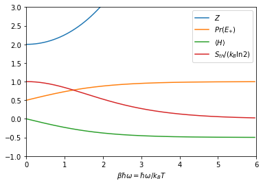

```python
N, bhw, db = symbols('N bhw db')
N = 150
db = (6-0)/N
bv = np.zeros(N)
Pp = np.zeros(N)
Z = np.zeros(N)
Em = np.zeros(N)
Sth = np.zeros(N)
bhw = -db
for j in range(0,N):
    bhw += db
    bv[j] = bhw
    Z[j] = 2*cosh(bhw/2)
    Pp[j] = exp(bhw/2)/Z[j]
    Em[j] = -(1/2)*tanh(bhw*1/2)
    Sth[j] = (-(bhw/2)*tanh(bhw/2) + ln(2*cosh(bhw/2)))/ln(2)
plt.xlabel(r'$\beta\hbar\omega = \hbar\omega/k_{B}T$')
plt.plot(bv, Z, label=r'$Z$')
plt.plot(bv, Pp, label=r'$Pr(E_{+})$')
plt.plot(bv, Em, label=r'$\langle H\rangle$')
plt.plot(bv, Sth, label=r'$S_{th}/(k_{B}\ln2)$')
axes = plt.gca()
axes.set_xlim([0,6])
axes.set_ylim([-1,3])
plt.legend()
plt.show()
```